# stats 369 a2

Lawrence May

22/08/2020

Using the data from week 2 of January 2016, construct a model that predicts the amount of a tip. Evaluate the mean squared error of this model on the data from week 4 of January 2016. Write a report that describes how you constructed the model and how accurate it is.

Submit the rmd and the knitted pdf or html.

Notes:

1. The data sets are fairly large. Each one has a couple of million records. You should still be able to run `regsubsets` and `lm` fairly quickly.
2. As the data dictionary indicates, tip information is not available for all trips
3. These data have not been cleaned; they are as they came from the data provider.
4. You will want to recode variables such as pickup and dropoff time and location into categories: they will not have linear relationships with tip amount. Some graphical exploration is likely to be helpful in addition to thinking about the problem. If you have problems drawing graphs because of the size of the data, taking a random subsample of, say, 10% of it can be useful.

```r
library(tidyverse)
library(lubridate)
library(leaps)
library(leaflet)
library(forcats)
library(rgdal)
library(sp)

taxi <- read_csv("/Users/lawrence/Desktop/assignment 2/week2.csv")
 taxi <- taxi %>%
   mutate(dropoff_datetime = tpep_dropoff_datetime,
          pickup_datetime = tpep_pickup_datetime,
         dow = wday(pickup_datetime,label=TRUE,abbr=TRUE, week_start = 1),
          hour_trip_start = factor(hour(pickup_datetime)),
          trip_duration = as.numeric(difftime(dropoff_datetime,pickup_datetime,units="mins")),
          payment_type_label = fct_recode(factor(payment_type),
                                         "Credit Card"="1",
                                          "Cash"="2",
                                          "No Charge"="3",
                                          "Other"="4"),
          .keep=c("unused"))
```

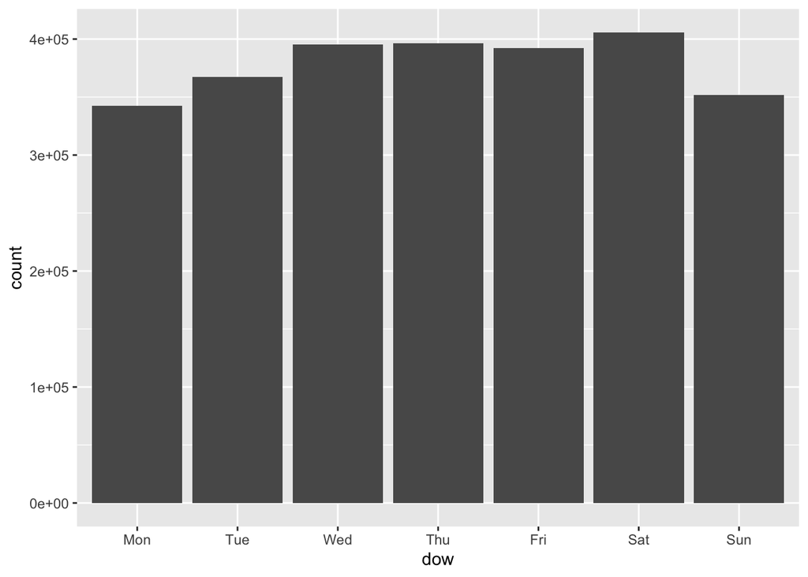

```r
# look at trip counts by day of week
taxi %>% ggplot( aes(x=dow)) + geom_bar()
```

Plot for daily pattern

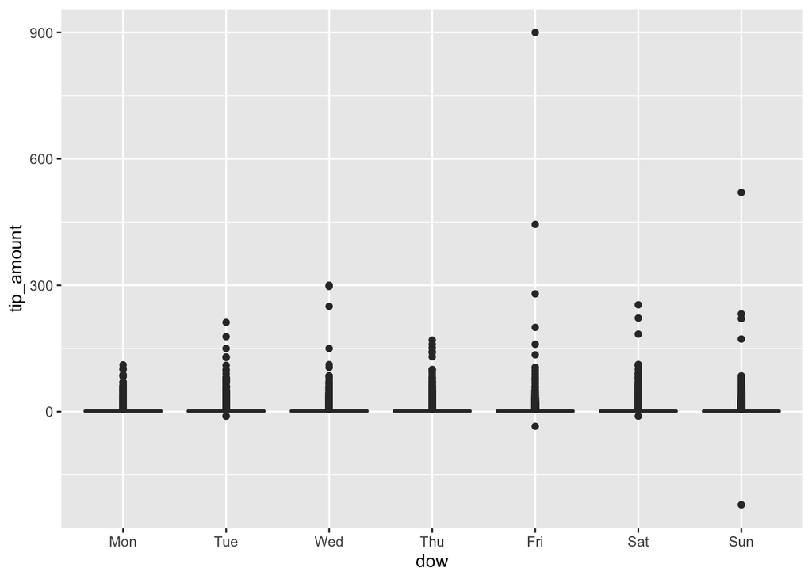

```r
 taxi %>% ggplot(aes(x=dow,y=tip_amount)) + geom_boxplot()
```

It appears as if most taxi trips are taken on Saturdays, however some of the highest number of tips are being paid on Fridays and Sundays. This could potentially be due to drunk people being a bit more generous when it comes to tips? Also there appear to be some negative tips which will need to be filtered out.

Filter out implausible and likely errornous observations, only payments made by Credit Card contain useful tip information: –>

```r
 taxi <- taxi %>%
   filter(trip_duration < 120, trip_duration > 0, fare_amount >= 0, passenger_count > 0, extra >= 0, tip_amount >= 0)
 #Filter out trips that took less than no time at all and longer than 2 hours, fares smaller than 0 and fares without any passengers as well as negative tips.
#Filters only trips paid by Credit card, as cash tips are not recorded

#taxi<-taxi[taxi$payment_type_label=="Credit Card",]
 #MTA tax and improvement surcharge same for all trips -> meaningless
 taxi <- taxi %>% select(-c(total_amount,mta_tax,improvement_surcharge,payment_type_label))


 #Creates categorical pickup time variable
 taxi <- taxi %>% mutate(pickup_time = as.factor(ifelse(dow %in% c("Sat","Sun") & hour_trip_start %in% 8:17, "Weekend - Daytime",
                                      ifelse(dow %in% c("Mon","Tue","Wed","Thu","Fri") & hour_trip_start %in% 8:17, "Weekday - Daytime",
                                   ifelse(dow %in% c("Mon","Tue","Wed","Thu","Fri") & hour_trip_start %in% 3:7, "Weekday - EarlyMorning",
                                       ifelse(dow %in% c("Sat","Sun") & hour_trip_start %in% 3:7, "Weekend - EarlyMorning",
                                      ifelse(dow %in% c("Sat","Sun") & hour_trip_start %in% 18:21, "Weekend - Evening",
                                       ifelse(dow %in% c("Mon","Tue","Wed","Thu","Fri") & hour_trip_start %in% 18:21, "Weekday - Evening",                                        ifelse(dow %in% c("Sat","Sun") & hour_trip_start %in% c(22,23,0,1,2), "Weekend - LateNight",                                                 "Weekday - LateNight")))))))))

taxi <- taxi %>% select(-c(dropoff_datetime,pickup_datetime,hour_trip_start,dow)) #Information all stored in categorical pickup_time variable
```

Looking at pickup and dropoff locations:

```r
# take a small subset so we can plot quickly -->
sm_taxi <- taxi %>% sample_n(1e4)
   # plot on a map
leaflet(sm_taxi) %>%
   addTiles() %>%
  addCircleMarkers(~pickup_longitude,~pickup_latitude, radius=2,stroke = FALSE, opacity=1, fillOpacity =1)
```

[interactive chart not shown]

There to appear to be some taxi trips that started in the cap verdian islands, they are certainly not correct and will need to be filtered out.

```r
 #There appear to be some weird outliers, need to filter out -->
 ## Use a simple bounding box for the NY area and filter #:https://www1.nyc.gov/assets/planning/download/pdf/data-maps/open-data/nybb_metadata.pdf?ver=20b -->
 min_lat <- 40.495992
max_lat <- 40.915568
 min_long <- -74.257159
 max_long <- -73.699215
 taxi <- taxi %>% filter(pickup_longitude > min_long, pickup_longitude < max_long, pickup_latitude > min_lat, pickup_latitude < max_lat)


 #Thanks Lisa!
# source: https://data.cityofnewyork.us/City-Government/Borough-Boundaries/tqmj-j8zm)
  # get shapefile (as map layer) download and unzip to a folder.
# nyc.shp <- readOGR('/Users/lawrence/Google Drive/UNI/current/Stats 369/assignment 2/Borough Boundaries')
#
#  #Pickup
#  mydf <- structure(list(
#    longitude = taxi$pickup_longitude, # use pickup point as example.
#    latitude = taxi$pickup_latitude),
#    .Names = c('longitude', 'latitude'),
#   class = 'data.frame',
#    row.names = c(NA, nrow(taxi)))
#
#
#  xy <- mydf[,c(1,2)]
#  spdf <- SpatialPointsDataFrame(coords = xy,
#                              data = mydf,
#                               proj4string = CRS(proj4string(nyc.shp)))
#
#  # overlay
#  results <- over(spdf, nyc.shp) # NA = unmatched/outside polygon
#
#  taxi$pickup_loc <- results$boro_name  #Add to taxi df
#
#
#  #Dropoff
#  mydf2 <- structure(list(
#    longitude = taxi$dropoff_longitude, # use pickup point as example.
#    latitude = taxi$dropoff_latitude),
#    .Names = c('longitude', 'latitude'),
#    class = 'data.frame',
#    row.names = c(NA, nrow(taxi))
#  )
#
# xy <- mydf2[,c(1,2)]
# spdf2 <- SpatialPointsDataFrame(coords = xy,
#                               data = mydf2,
#                             proj4string = CRS(proj4string(nyc.shp)))

#results <- over(spdf2, nyc.shp) # NA = unmatched/outside polygon

#taxi$dropoff_loc <- results$boro_name

#taxi <- taxi %>% select(-c(pickup_longitude,pickup_latitude,dropoff_longitude,dropoff_latitude))
```

```r
# taxi$pickup_loc<-as.factor(taxi$pickup_loc)
# taxi$dropoff_loc<-as.factor(taxi$dropoff_loc)
#
# taxi$pickup_loc<- taxi$pickup_loc %>% fct_explicit_na(na_level = 'OutsideNYC')   #Replace NA with OutsideNYC
# taxi$dropoff_loc<- taxi$dropoff_loc %>% fct_explicit_na(na_level = 'OutsideNYC')

fit <- lm(tip_amount ~ ., data= taxi)
summary(fit)
```

```
##
## Call:
## lm(formula = tip_amount ~ ., data = taxi)
##
## Residuals:
##     Min      1Q  Median      3Q     Max
## -144.36   -0.98    0.31    0.86  894.42
##
## Coefficients:
##                                     Estimate Std. Error t value Pr(>|t|)
## (Intercept)                       -1.689e+02  3.649e+00 -46.286  < 2e-16 ***
## VendorID                           2.180e-02  2.613e-03   8.342  < 2e-16 ***
## passenger_count                   -1.657e-02  9.814e-04 -16.883  < 2e-16 ***
## trip_distance                      7.114e-02  1.020e-03  69.714  < 2e-16 ***
## pickup_longitude                  -1.620e+00  4.091e-02 -39.605  < 2e-16 ***
## pickup_latitude                    1.219e+00  5.098e-02  23.914  < 2e-16 ***
## RatecodeID                        -1.568e-02  3.522e-03  -4.452 8.52e-06 ***
## store_and_fwd_flagY               -8.790e-02  1.702e-02  -5.164 2.41e-07 ***
## dropoff_longitude                 -6.410e-01  1.360e-02 -47.118  < 2e-16 ***
## dropoff_latitude                  -1.174e+00  2.470e-02 -47.531  < 2e-16 ***
## fare_amount                        1.043e-01  3.672e-04 283.977  < 2e-16 ***
## extra                              3.297e-02  4.376e-03   7.534 4.92e-14 ***
## tolls_amount                       1.701e-01  1.022e-03 166.387  < 2e-16 ***
## trip_duration                      2.288e-03  2.606e-04   8.777  < 2e-16 ***
## pickup_timeWeekday - EarlyMorning -6.434e-02  5.219e-03 -12.328  < 2e-16 ***
## pickup_timeWeekday - Evening       1.520e-01  4.329e-03  35.116  < 2e-16 ***
## pickup_timeWeekday - LateNight     5.282e-02  4.684e-03  11.277  < 2e-16 ***
## pickup_timeWeekend - Daytime      -1.330e-01  4.101e-03 -32.430  < 2e-16 ***
## pickup_timeWeekend - EarlyMorning -2.640e-01  8.325e-03 -31.714  < 2e-16 ***
## pickup_timeWeekend - Evening      -5.347e-02  5.599e-03  -9.550  < 2e-16 ***
## pickup_timeWeekend - LateNight    -4.686e-03  5.359e-03  -0.874    0.382
## ---
## Signif. codes:  0 '***' 0.001 '**' 0.01 '*' 0.05 '.' 0.1 ' ' 1
##
## Residual standard error: 1.998 on 2602753 degrees of freedom
## Multiple R-squared:  0.3383, Adjusted R-squared:  0.3383
## F-statistic: 6.653e+04 on 20 and 2602753 DF,  p-value: < 2.2e-16
```

```r
taxi <- taxi %>% select(-c(VendorID,passenger_count))
```

Fitting a cross validated model

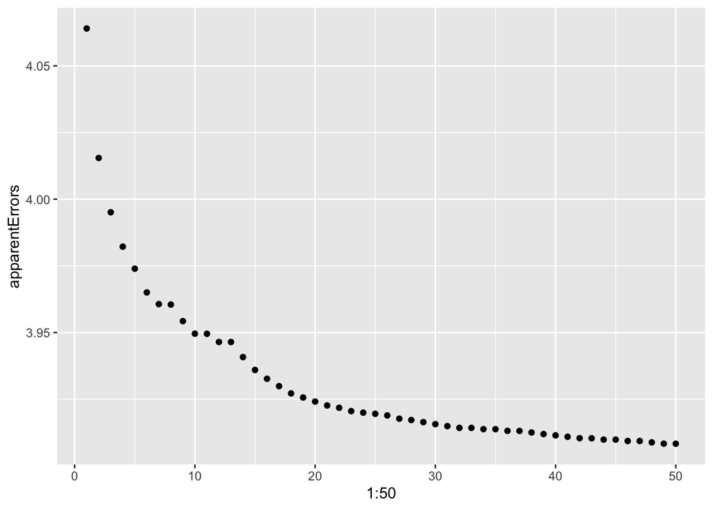

```r
mf<-model.frame(tip_amount~.^2, data=taxi)
X<-model.matrix(tip_amount~.^2, mf)[,-1]


subsets1.reg = regsubsets(X, taxi$tip_amount, nvmax = 50, method = "backward")
subsets1.summary = summary(subsets1.reg)
apparentErrors = subsets1.summary$rss / (nrow(taxi) - 1:50)
qplot(y = apparentErrors, x= 1:50)
```

Apparent error tends to go down the more predictive variables are added, not surprisingly.

Get allyhat function from xvalcode

```r
allyhat<-function(xtrain, ytrain, xtest,lambdas,nvmax=50){
  n<-nrow(xtrain)
  yhat<-matrix(nrow=nrow(xtest),ncol=length(lambdas))
  search<-regsubsets(xtrain,ytrain, nvmax=nvmax, method="back")
  summ<-summary(search)
  for(i in 1:length(lambdas)){
    penMSE<- n*log(summ$rss)+lambdas[i]*(1:nvmax)
    best<-which.min(penMSE)  #lowest AIC
    betahat<-coef(search, best) #coefficients
    xinmodel<-cbind(1,xtest)[,summ$which[best,]] #predictors in that model
    yhat[,i]<-xinmodel%*%betahat
  }
  yhat
}
```

```r
y = taxi$tip_amount
n<-nrow(X)
folds<-sample(rep(1:10,length.out=n))
lam<-c(1,10,50,200,4000)
fitted<-matrix(nrow=n,ncol=length(lam))
for(k in 1:10){
  train<- (1:n)[folds!=k]
  test<-(1:n)[folds==k]
  fitted[test,]<-allyhat(X[train,],y[train],X[test,],lam,nvmax = 50)
}
colMeans((y-fitted)^2)
```

```
## [1] 3.974816 3.974816 3.974794 3.976281 3.996952
```

Importing and cleaning test set

```r
taxi.test <- read_csv("/Users/lawrence/Desktop/assignment 2/week4.csv")
taxi.test <- taxi.test %>%
  mutate(dropoff_datetime = tpep_dropoff_datetime,
         pickup_datetime = tpep_pickup_datetime,
         dow = wday(pickup_datetime,label=TRUE,abbr=TRUE, week_start = 1),
         hour_trip_start = factor(hour(pickup_datetime)),
         trip_duration = as.numeric(difftime(dropoff_datetime,pickup_datetime,units="mins")),
         payment_type_label = fct_recode(factor(payment_type),
                                         "Credit Card"="1",
                                         "Cash"="2",
                                         "No Charge"="3",
                                         "Other"="4"),
         .keep=c("unused")) %>%
  filter(trip_duration < 120, trip_duration > 0, fare_amount >= 0, passenger_count > 0, extra >= 0, trip_distance <= max(taxi$trip_distance)) #Filter out trips that took less than no time at all and longer than 2 hours, fares smaller than 0 and fares without any passengers
#Filters only trips paid by Credit card, as cash tips are not recorded

#Creates categorical pickup time variable
taxi.test <- taxi.test %>% mutate(pickup_time = as.factor(ifelse(dow %in% c("Sat","Sun") & hour_trip_start %in% 8:17, "Weekend - Daytime",
                                      ifelse(dow %in% c("Mon","Tue","Wed","Thu","Fri") & hour_trip_start %in% 8:17, "Weekday - Daytime",
                                    ifelse(dow %in% c("Mon","Tue","Wed","Thu","Fri") & hour_trip_start %in% 3:7, "Weekday - EarlyMorning",
                                      ifelse(dow %in% c("Sat","Sun") & hour_trip_start %in% 3:7, "Weekend - EarlyMorning",
                                      ifelse(dow %in% c("Sat","Sun") & hour_trip_start %in% 18:21, "Weekend - Evening",
                                      ifelse(dow %in% c("Mon","Tue","Wed","Thu","Fri") & hour_trip_start %in% 18:21, "Weekday - Evening",
                                      ifelse(dow %in% c("Sat","Sun") & hour_trip_start %in% c(22,23,0,1,2), "Weekend - LateNight",                                                 "Weekday - LateNight")))))))))

#taxi.test<-taxi.test[taxi.test$payment_type_label=="Credit Card",]

taxi.test <- taxi.test %>% select(-c(VendorID,passenger_count,total_amount,mta_tax,improvement_surcharge,payment_type_label,dropoff_datetime,pickup_datetime,dow,hour_trip_start)) #Information all stored in categorical pickup_time

taxi.test <- taxi.test %>% filter(pickup_longitude > min_long, pickup_longitude < max_long, pickup_latitude > min_lat, pickup_latitude < max_lat)

# #Pickup
# mydf <- structure(list(
#   longitude = taxi.test$pickup_longitude, # use pickup point as example.
#   latitude = taxi.test$pickup_latitude),
#   .Names = c('longitude', 'latitude'),
#   class = 'data.frame',
#   row.names = c(NA, nrow(taxi.test))
# )
#
#
# xy <- mydf[,c(1,2)]
# spdf <- SpatialPointsDataFrame(coords = xy,
#                                data = mydf,
#                                proj4string = CRS(proj4string(nyc.shp)))
#
# # overlay
# results <- over(spdf, nyc.shp) # NA = unmatched/outside polygon
#
# taxi.test$pickup_loc <- results$boro_name  #Add to taxi df
#
#
# #Dropoff
# mydf2 <- structure(list(
#   longitude = taxi.test$dropoff_longitude, # use pickup point as example.
#   latitude = taxi.test$dropoff_latitude),
#   .Names = c('longitude', 'latitude'),
#   class = 'data.frame',
#   row.names = c(NA, nrow(taxi.test))
# )
#
# xy <- mydf2[,c(1,2)]
# spdf2 <- SpatialPointsDataFrame(coords = xy,
#                                data = mydf2,
#                                proj4string = CRS(proj4string(nyc.shp)))
#
# # overlay
# results <- over(spdf2, nyc.shp) # NA = unmatched/outside polygon

#taxi.test$dropoff_loc <- results$boro_name
#taxi.test <- taxi.test %>% select(-c(pickup_longitude,pickup_latitude,dropoff_longitude,dropoff_latitude))

#taxi.test$pickup_loc<-as.factor(taxi.test$pickup_loc)
#taxi.test$dropoff_loc<-as.factor(taxi.test$dropoff_loc)

#taxi.test$pickup_loc<- taxi.test$pickup_loc %>% fct_explicit_na(na_level = 'OutsideNYC')   #Replace NA with OutsideNYC
#taxi.test$dropoff_loc<- taxi.test$dropoff_loc %>% fct_explicit_na(na_level = 'OutsideNYC')

y_txts<-taxi.test$tip_amount #Ys needed for testing true mspe
```

```r
lam = 1
search = regsubsets(X, y, nvmax = 50, method = "backward")
summ = summary(search)
aic = nrow(X)*log(summ$rss)+lam*(1:50)
best = which.min(aic)
betahat = coef(search, best)
```

Most of the predictor variables in the final model are related to trip distance, fare amount, tolls and pickup or drop-off location. This is what would be expected, given that the tip is usually expected to be 15-20% of the fare it makes sense that is one of the most significant predictors. Same goes for distance, which is likely highly correlated with fare amount. Pickups and drop-offs in wealthier suburbs will are more likely to generate large tips than from poorer suburbs due to different clientele of course.

Testing the model on the week4 taxi test set and evaluating true MSPE

```r
mf<-model.frame(tip_amount~.^2, data=taxi.test)
Xfull<-model.matrix(tip_amount~.^2, mf)[,summ$which[best,]]
fitted = Xfull%*%betahat

MSPEfull = sum((y_txts - fitted)^2) / length(fitted)
MSPEfull
```

```
## [1] 4.850151
```

The true unbiased MSPE is 4.9, slightly above the apparent error which was around 4.

Report

The first step in constructing the model was cleaning the data, which had a few outliers that were likely to be errors that were likely going to cause problems later on. Due to the large size of the data I decided to just remove these values as there were enough remaining observations that I was able to build the model with. These outliers were taxi trips that did not start in the geospatial coordinates that New York City is located in (some started somewhere in the Cape Verdian Islands according to the coordinates). I also decided to remove taxi trips that took longer than 2 hours or less than 0 hours, that had less than 1 passenger or that had a fare, tip or other charge smaller than zero. These were all likely to be error prone observations.

I also converted the time variables into factors as they will likely not have linear properties (i.e. the tip sizes on a Wednesday afternoon will likely not be too different to that on a Tuesday afternoon, while that on a Friday or Saturday night might be quite different however). I have therefore created a new variable pickup_time which is a factor with levels “Weekend - Daytime”,“Weekday - Daytime”, “Weekday - EarlyMorning”, “Weekend - EarlyMorning”,“Weekend - Evening”,“Weekday - Evening”,“Weekend - LateNight”,“Weekday - LateNight” to capture the similarities that 1am on a Friday night and 3am on a Saturday have compared to 2pm on a Monday and 3pm on a Thursday.

EDIT: Unfortunately changing the geospatial data into categorical variables caused major problems with regsubsets, I have therefore decided to keep the spacial information in langitude and longitude form as that still will provide some information on tips (i.e. further North might have a different demographic than further South (e.g Bronx vs Staten Island)). (After filtering out all trips that did not start in the New York area I also decided to go with Lisa’s suggestions (Thanks Lisa!) and converted the geospacial information into factors of which Borrough of New York the trip ended or finished, again because it will likely be meaningful to say a trip started in manhattan or the bronx compared to 48 degrees or 48.3 degrees latitude.)

```r
betahat
```

```
##                                        (Intercept)
##                                      -2.030391e+05
##                                      trip_distance
##                                       1.512724e+01
##                                   pickup_longitude
##                                      -2.749563e+03
##                                    pickup_latitude
##                                       4.980059e+03
##                                  dropoff_longitude
##                                      -8.634096e+02
##                                   dropoff_latitude
##                                      -1.574281e+03
##                  pickup_timeWeekday - EarlyMorning
##                                       1.802402e+02
##                     pickup_timeWeekday - LateNight
##                                       1.115387e+00
##                       pickup_timeWeekend - Daytime
##                                       1.986588e+02
##                  pickup_timeWeekend - EarlyMorning
##                                       3.201898e+02
##                       pickup_timeWeekend - Evening
##                                       2.275385e+02
##                      trip_distance:pickup_latitude
##                                      -3.697710e-01
##                           trip_distance:RatecodeID
##                                       3.069825e-02
##                          trip_distance:fare_amount
##                                      -8.224582e-04
##                        trip_distance:trip_duration
##                                      -6.512537e-04
##         trip_distance:pickup_timeWeekday - Evening
##                                      -1.141035e-01
##       trip_distance:pickup_timeWeekday - LateNight
##                                       9.139585e-02
##                   pickup_longitude:pickup_latitude
##                                       6.744003e+01
##                 pickup_longitude:dropoff_longitude
##                                      -1.740058e+01
##                  pickup_longitude:dropoff_latitude
##                                      -3.159942e+01
```

[output cut: 47 more lines]

```
##                                      -1.972989e+00
##          tolls_amount:pickup_timeWeekday - Evening
##                                      -9.263600e-02
##        tolls_amount:pickup_timeWeekday - LateNight
##                                      -8.152909e-02
##          tolls_amount:pickup_timeWeekend - Daytime
##                                      -2.126546e-01
##          tolls_amount:pickup_timeWeekend - Evening
##                                      -1.198130e-01
##        tolls_amount:pickup_timeWeekend - LateNight
##                                      -1.233485e-01
##         trip_duration:pickup_timeWeekday - Evening
##                                      -2.735180e-02
##    trip_duration:pickup_timeWeekend - EarlyMorning
##                                      -2.885990e-02
```

Accuracy

I believe a good measure for the accuracy of the model (i.e a good comparison for the MSPE) would be to compare the predictive performance of the model with a null-model of just the average tip in week 2 to predict week 4 tips.

```r
avg_tip=mean(taxi$tip_amount)
MSPEnull = sum((y_txts - avg_tip)^2) / length(y_txts)
MSPEnull
```

```
## [1] 7.152504
```